# matplotlib MATPLOTLIB_SOLUTIONS

# MATPLOTLIB SOLUTIONS

- Hope you gave all the tasks a go 😊

### **TASK 1: HORIZONTAL BAR CHART WITH FOR LOOP**

### **DESIRED INPUT/OUTPUT**

[figure not shown]

### **HINTS?**

1. Use the **range** and **len** functions.
2. Use the horizontal bar plot method with **np.sum** method with data variable, index by :i, and an axis equal to zero.
3. Use yticks with a **range** of 5.
4. Add a legend with title = **PRICES**.

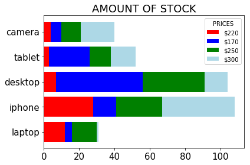

```python
import matplotlib.pyplot as plt, numpy as np
from mpl_toolkits.mplot3d import Axes3D
np.random.seed(12)
data = [np.random.randint(1, 50, 5),
        np.random.randint(1, 50, 5),
        np.random.randint(1, 50, 5),
        np.random.randint(1, 50, 5)]

stock = ["laptop", "iphone", "desktop", "tablet", "camera"]
prices = ["${}".format(i) for i in [220, 170, 250, 300, 400]]
col = ["r", "b", "g", "lightblue"]
for i in range(len(data)):
    plt.barh(bottom = np.arange(5), width = data[i],
             left = np.sum(data[:i], axis = 0),
             label = prices[i], color = ["r", "b", "g", "lightblue"][i])
    plt.yticks(np.arange(5), stock, fontsize = 15)
    plt.xticks(fontsize = 15)
    plt.title("AMOUNT OF STOCK", fontsize = 18)
    plt.legend(title = "PRICES", loc = "best")
plt.tight_layout()
plt.show()
```

### **TASK 2: 3D SCATTER PLOT WITH CONTROL FLOW**

### **DESIRED INPUT/OUTPUT**

```
control(x, y, z)
Enter a range for val 1: 20
Enter a range for val 2: 150
```

[figure not shown]

### **HINTS?**

1. Use the add_subplot method with a projection equal to **"3d"**.
2. Add **scatter** plot method 3 times, index the colors using the **for** loop.
3. In the **scatter** method, use the linewidth and edgecolors parameters, s = 400.
4. Ensure the plot has a grid.

```
Enter a range for val 1: 20
Enter a range for val 2: 150
```

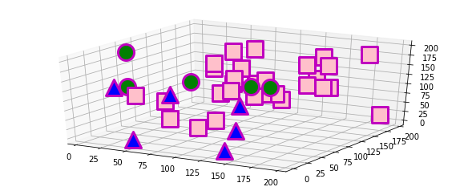

```python
np.random.seed(100)
x = np.random.randint(1, 200, 40)
y = np.random.randint(1, 200, 40)
z = np.random.randint(1, 200, 40)
def control(x, y, z):
    val1 = eval(input("Enter a range for val 1: "))
    val2 = eval(input("Enter a range for val 2: "))
    col = ["pink", "b", "g"]
    fig = plt.figure(figsize = (10, 4))
    ax = fig.add_subplot(111, projection = "3d")
    for a, b, c1 in  zip(x, y, z):
        if a >=  val1 and b >= val1:
            ax.scatter(a, b, c1, s=400, c = col[0], marker = "s",
                      edgecolors = "m", linewidth = 3)
        elif a > val1  and a < val2:
            ax.scatter(a, b, c1, s=400, c = col[1], marker = "^",
                      edgecolors = "m", linewidth = 3)
        else:
            ax.scatter(a, b, c1, s=400, c = col[2], marker = "o",
                      edgecolors = "m", linewidth = 3)
    plt.grid(True)
    plt.show()

control(x, y, z)
```

### **TASK 3: SUBPLOT 2 LINES AND 2 HEAT MAPS**

### **DESIRED INPUT/OUTPUT**

[figure not shown]

### **HINTS?**

1. Add a total of 4 subplot methods.
2. Use 2 plot and 2 imshow methods.
3. Ensure 2 color bars for the heatmaps.

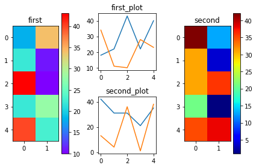

```python
np.random.seed(300) ; fig1 = plt.figure()
num1 = np.random.randint(1, 50, 10).reshape(5, 2)
num2 = np.random.randint(1, 50, 10).reshape(5, 2)

plt.subplot(131)
plt.title("first")
plt.imshow(num1, cmap = "rainbow")
plt.colorbar()

plt.subplot(133)
plt.title("second")
plt.imshow(num2, cmap = "jet")
plt.colorbar()

plt.subplot(232)
plt.title("first_plot")
plt.plot(num1)

plt.subplot(235)
plt.title("second_plot")
plt.plot(num2)

plt.tight_layout()
plt.show()
```

### **TASK 4: ADD TEXT TO PIE CHART**

### **DESIRED INPUT/OUTPUT**

[figure not shown]

### **HINTS?**

1. For the pie method, make sure autopct parameter has a float as a string of 1.2 and three % signs.
2. In all the text methods, use bbox parameter as a dictionary with **facecolor**, **alpha** and **pad** keys.

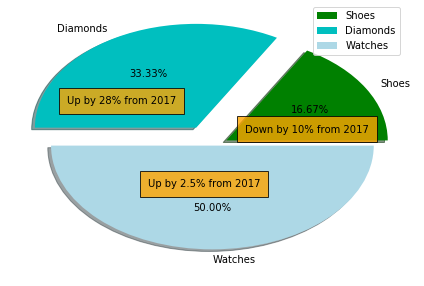

```python
items = "Shoes", "Diamonds", "Watches" ;    color = "g", "c", "lightblue"
sizes = 15, 30, 45  ; explosion = 0.1, 0.2, 0.0
plt.figure()
plt.pie(sizes, autopct = "%1.2f%%", explode = explosion, labels = items,
        shadow = True, radius = 1,  colors = color, startangle = 0)

plt.text(-0.9,0.4, "Up by 28% from 2017", fontsize =10,
        bbox = {"facecolor": "orange", "alpha": .8,
               "pad": 8})

plt.text(0.2,0.13, "Down by 10% from 2017", fontsize =10,
        bbox = {"facecolor": "orange", "alpha": .8,
               "pad": 8})

plt.text(-0.4, -0.4, "Up by 2.5% from 2017", fontsize =10,
        bbox = {"facecolor": "orange", "alpha": .8,
               "pad": 8})

plt.legend(items, fontsize = 10, loc =(0.75, 0.85))
plt.tight_layout()
plt.show()
```

### **TASK 5: BASIC 3D BAR PLOT WITH LEGEND**

### **DESIRED INPUT/OUTPUT**

[figure not shown]

### **HINTS?**

1. For z, use the **rand** method of 2 by 2.
2. For xpos, ypos, and dz, use the **flatten** method.
3. Use the bar3d method with 7 parameters; 3 for position, 3 for dimensions and 1 for colors.
4. Add labels and title.

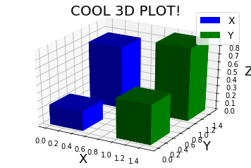

```python
fig = plt.figure()
x = np.array(range(0, 2), float)
y = x.copy()
# CREATES A 2 BY 2 2D ARRAY WHICH IS A MATRIX
z = np.random.rand(2,2)
xpos, ypos = np.meshgrid(x, y)
colors = ["b", "g"]*2
xpos = xpos.flatten()
ypos = ypos.flatten()
zpos = np.zeros_like(xpos)
dx = 0.5 * np.ones_like(zpos)
dy = dx.copy()
dz = z.flatten()

ax = fig.add_subplot(111, projection = "3d")
labels = ["X", "Y"]
x_leg = plt.Rectangle((0, 0), 1,1, fc = "b")
y_leg = plt.Rectangle((0, 0), 1,1, fc = "g")
ax.set_title("COOL 3D PLOT!", fontsize = 20)

ax.legend([x_leg, y_leg], labels, fontsize = 14)
ax.bar3d(xpos, ypos, zpos, dx, dy, dz, color = colors)
ax.set_xlabel("X", fontsize = 18)
ax.set_ylabel("Y", fontsize = 18)
ax.set_zlabel("Z", fontsize = 18)
plt.show()
```